# Ie360 Spring22 HW2

Ersu DEDEAĞAOĞLU / 2018402081

5/11/2022

# Introduction

This assignment mainly aims to predict the unleaded gasoline sale in 2007 for each quarter, using the past values and some potentially related input variables. These variables are summarized as follows:

UGS: Unleaded gasoline sale in a given quarter(output variable),  
RNUV: An index indicating the rate of new unleaded gasoline using vehicles being added to the traffic in a quarter,  
PU: Average price (adjusted with an index) of a liter of unleaded gasoline in a quarter,  
PG: Average price (adjusted with an index) of a liter of diesel gasoline in a quarter,  
NUGV: Number of unleaded gasoline using vehicles in the traffic,  
NDGV: Number of diesel gasoline using vehicles in the traffic (per 1000 people),  
GNPA: Agriculture component of Gross National Product (adjusted with an index),  
GNPC: Commerce component of Gross National Product (adjusted with an index),  
GNP: Grand total for GNP (agriculture, commerce and other components total).

# Data Manipulation

## Libraries

```r
library(readxl)
library(skimr)
library(janitor)
library(readr)
library(tidyverse)
library(fBasics)
library(dplyr)
library(data.table)
library(writexl)
library(scales)
library(plyr)
library(zoo)
library(lubridate)
library(ggplot2)
library(forecast)
library(corrplot)
library(ggcorrplot)
library(xts)
```

## Import and arrange the data

```r
setwd("C:/Users/Erkut/Desktop/ie 360")

data <- read.csv("IE360_Spring22_HW2_data_.csv")
data <- data[,c(1:11)]
data
```

```
##    Quarter Unleaded.Gasoline.Sale..UGS.   RNUV X..LPG.Vehicles..NLPG.
## 1  2000_Q1                      1128971 0.0146                 940000
## 2  2000_Q2                      1199569 0.0205                 941000
## 3  2000_Q3                      1370167 0.0207                 943500
## 4  2000_Q4                      1127548 0.0163                 948000
## 5  2001_Q1                      1033918 0.0071                 950000
## 6  2001_Q2                      1019754 0.0051                 955000
## 7  2001_Q3                      1209916 0.0041                 967500
## 8  2001_Q4                      1002789 0.0048                 990000
## 9  2002_Q1                       893722 0.0012                1000000
## 10 2002_Q2                      1027252 0.0032                1001000
## 11 2002_Q3                      1153265 0.0034                1003500
## 12 2002_Q4                       991981 0.0044                1008000
## 13 2003_Q1                       806257 0.0019                1010000
## 14 2003_Q2                       960556 0.0056                1048000
```

[output cut: 117 more lines]

```r
# data <- data[data$Unleaded.Gasoline.Sale..UGS.!="",]
data$Quarter <- as.yearqtr(data$Quarter, format = "%Y_Q%q")
str(data)
```

```
## 'data.frame':    32 obs. of  11 variables:
##  $ Quarter                              : 'yearqtr' num  2000 Q1 2000 Q2 2000 Q3 2000 Q4 ...
##  $ Unleaded.Gasoline.Sale..UGS.         : int  1128971 1199569 1370167 1127548 1033918 1019754 1209916 1002789 893722 1027252 ...
##  $ RNUV                                 : num  0.0146 0.0205 0.0207 0.0163 0.0071 0.0051 0.0041 0.0048 0.0012 0.0032 ...
##  $ X..LPG.Vehicles..NLPG.               : int  940000 941000 943500 948000 950000 955000 967500 990000 1000000 1001000 ...
##  $ Price.of.Unleaded.Gasoline..PU.      : num  469 459 440 402 412 ...
##  $ Price.of.Diesel.Gasoline..PG.        : num  356 345 327 301 306 ...
##  $ X..Unleaded.Gasoline.Vehicles..NUGV. : int  4647500 4742876 4840931 4919685 4954754 4980204 5000446 5024693 5030810 5046960 ...
##  $ X..of.Diesel.Gasoline.Vehicles..NDGV.: num  282 284 287 288 288 ...
##  $ GNP.Agriculture                      : int  1040173 1760460 6974808 3267125 1004528 1449357 5890424 1940854 832953 1419764 ...
##  $ GNP.Commerce                         : int  3483132 4525451 5915204 4929778 3418387 4359831 5925547 4559190 3374849 4363782 ...
##  $ GNP.Total                            : int  18022686 21797130 30050207 24480153 15832648 20296918 28017963 22656812 18393446 20382635 ...
```

```r
### create ugs data
data_ugs <- data[,2]
data_ugs <- data_ugs[!is.na(data_ugs)]
```

## Insight

```r
datats <- ts(data_ugs,freq=4,start=c(2000,1))
str(datats)
```

```
##  Time-Series [1:28] from 2000 to 2007: 1128971 1199569 1370167 1127548 1033918 1019754 1209916 1002789 893722 1027252 ...
```

```r
datats
```

```
##         Qtr1    Qtr2    Qtr3    Qtr4
## 2000 1128971 1199569 1370167 1127548
## 2001 1033918 1019754 1209916 1002789
## 2002  893722 1027252 1153265  991981
## 2003  806257  960556 1104825  934022
## 2004  832350  975165 1094823  854517
## 2005  762559  890693 1040946  793399
## 2006  736580  877614  946783  872000
```

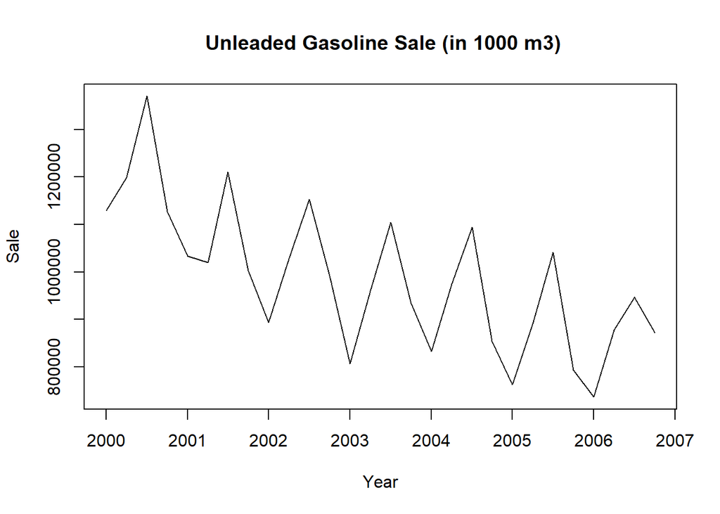

```r
ts.plot(datats,xlab = "Year", ylab = "Sale",main=" Unleaded Gasoline Sale (in 1000 m3)")
```

As it can be seen, mean is non-stationary when the variance seems stationary. It also useful to check the trend of the data.

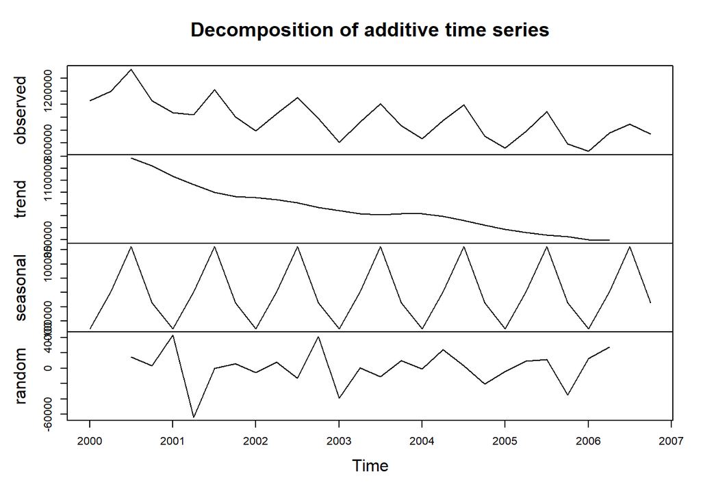

```r
dec_data<-decompose(datats, type="additive")
plot(dec_data)
```

This decomposition function helps us to visualize the components of time series data. As we can clearly see, there is a decreasing trend in UGS, which states that the mean is non-stationary.

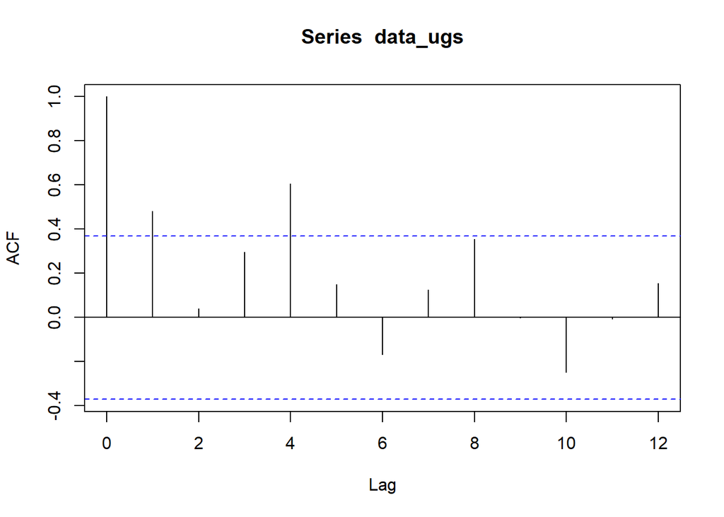

```r
acf(data_ugs, lag = 12)
```

There seems a high autocorrelation at lag 1 and lag 4. Lag 1 comes from the idea that when we think of two consequent quarters, the letter affects the next one. Lag 4 is high since the same quarter at the next year shows a similar behavior with the one in this year.

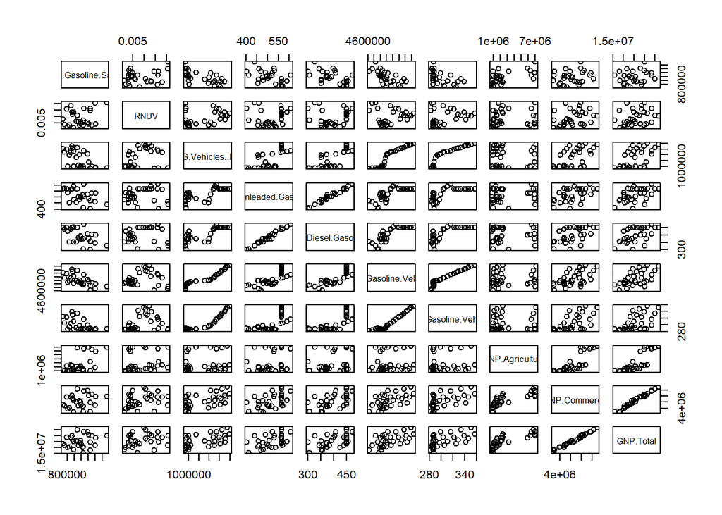

```r
pairs(data[,c(2:11)])
```

We should consider the relation between UGS and other variables. This pairs functions help us achieve this.

## Components and Lags

```r
### add trend and seasonality
trend <- 1:32
data$trend <- trend
data$quarter <- rep(1:4,8)
data$lag1 <- NA
data$lag4 <- NA

data$quarter <- as.factor(data$quarter)

for(i in 1:28){
  data$lag1[i+1] = data$Unleaded.Gasoline.Sale..UGS.[i]
}

for(i in 1:28){
  data$lag4[i+4] = data$Unleaded.Gasoline.Sale..UGS.[i]
}
```

# Model Building

```r
model <- lm(Unleaded.Gasoline.Sale..UGS. ~. - Quarter, data = data[1:28,])
summary(model)
```

```
##
## Call:
## lm(formula = Unleaded.Gasoline.Sale..UGS. ~ . - Quarter, data = data[1:28,
##     ])
##
## Residuals:
##    Min     1Q Median     3Q    Max
## -38364  -9454   -409   7421  33438
##
## Coefficients:
##                                         Estimate Std. Error t value Pr(>|t|)
## (Intercept)                            4.986e+06  2.057e+06   2.424   0.0416 *
## RNUV                                   3.504e+06  3.001e+06   1.168   0.2766
## X..LPG.Vehicles..NLPG.                -5.564e-01  2.999e-01  -1.855   0.1007
## Price.of.Unleaded.Gasoline..PU.        8.635e+02  1.604e+03   0.538   0.6049
## Price.of.Diesel.Gasoline..PG.         -2.634e+03  2.381e+03  -1.106   0.3008
## X..Unleaded.Gasoline.Vehicles..NUGV.  -1.521e+00  8.887e-01  -1.712   0.1253
## X..of.Diesel.Gasoline.Vehicles..NDGV.  1.718e+04  9.680e+03   1.775   0.1139
## GNP.Agriculture                       -4.690e-02  6.735e-02  -0.696   0.5059
## GNP.Commerce                           1.273e-01  1.153e-01   1.104   0.3016
## GNP.Total                             -1.510e-02  2.391e-02  -0.631   0.5454
## trend                                  2.338e+04  2.579e+04   0.907   0.3911
## quarter2                               3.018e+04  1.048e+05   0.288   0.7807
## quarter3                               4.411e+05  4.018e+05   1.098   0.3042
## quarter4                               1.900e+05  1.179e+05   1.611   0.1458
## lag1                                  -5.164e-01  3.120e-01  -1.655   0.1364
## lag4                                  -8.342e-02  2.660e-01  -0.314   0.7618
## ---
## Signif. codes:  0 '***' 0.001 '**' 0.01 '*' 0.05 '.' 0.1 ' ' 1
##
## Residual standard error: 29960 on 8 degrees of freedom
##   (4 observations deleted due to missingness)
## Multiple R-squared:  0.9796, Adjusted R-squared:  0.9414
## F-statistic: 25.63 on 15 and 8 DF,  p-value: 4.113e-05
```

Backward selection is used for variable selection. In this sense, all variables are added to the model as a first step. The first purpose is to select which variables to use, so at these first steps, trend and seasonality components are not removed. It can be observed that the significance of “PU” is lower among these variables. But, checking the meanings of these variables, price of the unleaded gasoline should significantly affect its sales. This problem probably occur from the fact that the number of observations are small, which results in some misleading outputs, and some variables are so correlated that the model gives them low significance to handle double counting errors. In this sense, it is highly useful to check correlation results among variables.

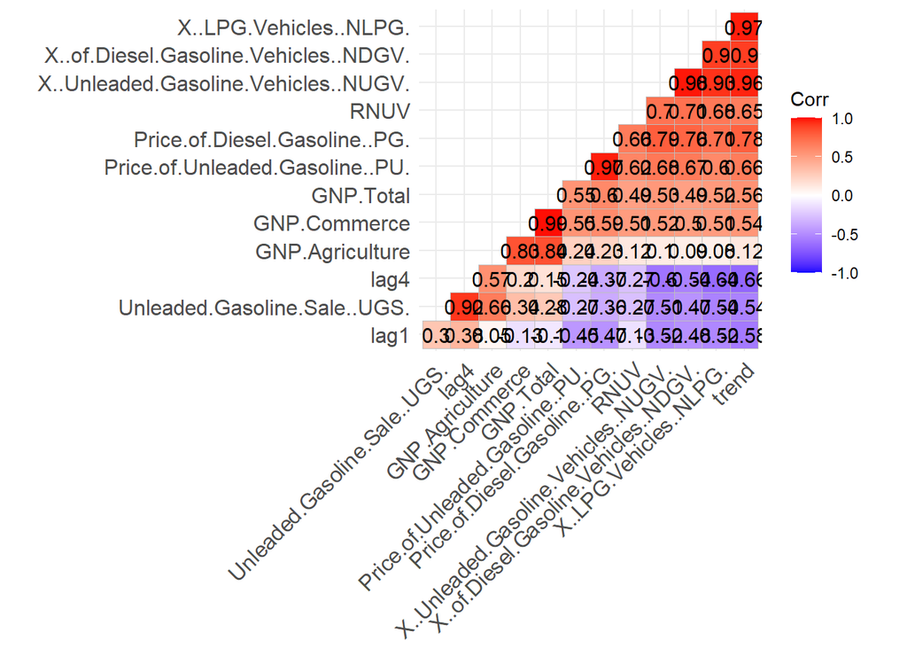

```r
temp_data <- data[!is.na(data$Unleaded.Gasoline.Sale..UGS. & data$lag1 & data$lag4),]
corr = cor(temp_data[,unlist(lapply(temp_data, is.numeric))])
ggcorrplot(corr,
           hc.order = TRUE,
           type='lower',
           lab=TRUE)
```

The variable pairs with high correlations are important because a good model includes less correlated variables. Therefore, as a first improvement, PG is removed considering that its significance value is not that much, and it has a large correlation with PU.

```r
model2 <- lm(Unleaded.Gasoline.Sale..UGS. ~. - Quarter - Price.of.Diesel.Gasoline..PG., data = data[1:28,])
summary(model2)
```

```
##
## Call:
## lm(formula = Unleaded.Gasoline.Sale..UGS. ~ . - Quarter - Price.of.Diesel.Gasoline..PG.,
##     data = data[1:28, ])
##
## Residuals:
##    Min     1Q Median     3Q    Max
## -45887 -10431    168  12013  35112
##
## Coefficients:
##                                         Estimate Std. Error t value Pr(>|t|)
## (Intercept)                            4.914e+06  2.082e+06   2.361   0.0426 *
## RNUV                                   3.082e+06  3.014e+06   1.023   0.3331
## X..LPG.Vehicles..NLPG.                -3.561e-01  2.421e-01  -1.471   0.1754
## Price.of.Unleaded.Gasoline..PU.       -8.737e+02  3.283e+02  -2.661   0.0260 *
## X..Unleaded.Gasoline.Vehicles..NUGV.  -1.543e+00  8.995e-01  -1.715   0.1205
## X..of.Diesel.Gasoline.Vehicles..NDGV.  1.804e+04  9.768e+03   1.846   0.0979 .
## GNP.Agriculture                       -1.231e-02  6.039e-02  -0.204   0.8430
## GNP.Commerce                           5.202e-02  9.422e-02   0.552   0.5943
## GNP.Total                             -8.320e-03  2.340e-02  -0.356   0.7304
## trend                                  1.030e+04  2.320e+04   0.444   0.6675
## quarter2                               7.119e+04  9.922e+04   0.718   0.4912
## quarter3                               3.776e+05  4.026e+05   0.938   0.3727
## quarter4                               2.252e+05  1.149e+05   1.960   0.0817 .
## lag1                                  -6.075e-01  3.047e-01  -1.994   0.0773 .
## lag4                                  -1.412e-01  2.640e-01  -0.535   0.6057
## ---
## Signif. codes:  0 '***' 0.001 '**' 0.01 '*' 0.05 '.' 0.1 ' ' 1
##
## Residual standard error: 30330 on 9 degrees of freedom
##   (4 observations deleted due to missingness)
## Multiple R-squared:  0.9765, Adjusted R-squared:  0.9399
## F-statistic: 26.71 on 14 and 9 DF,  p-value: 1.315e-05
```

Adjusted R squared is slightly decreased and SSE is slightly increased, but I think it can be overlooked because it prepares the ground for the model to develop better in the following steps. The next most insignificant variable is GNP.Agriculture, so it is removed.

```r
model3 <- lm(Unleaded.Gasoline.Sale..UGS. ~. - Quarter - Price.of.Diesel.Gasoline..PG.
             - GNP.Agriculture, data = data[1:28,])
summary(model3)
```

```
##
## Call:
## lm(formula = Unleaded.Gasoline.Sale..UGS. ~ . - Quarter - Price.of.Diesel.Gasoline..PG. -
##     GNP.Agriculture, data = data[1:28, ])
##
## Residuals:
##    Min     1Q Median     3Q    Max
## -44943  -8950   -644  11340  36871
##
## Coefficients:
##                                         Estimate Std. Error t value Pr(>|t|)
## (Intercept)                            4.728e+06  1.779e+06   2.658  0.02398 *
## RNUV                                   2.864e+06  2.679e+06   1.069  0.31014
## X..LPG.Vehicles..NLPG.                -3.352e-01  2.085e-01  -1.608  0.13895
## Price.of.Unleaded.Gasoline..PU.       -8.327e+02  2.467e+02  -3.375  0.00706 **
## X..Unleaded.Gasoline.Vehicles..NUGV.  -1.459e+00  7.600e-01  -1.919  0.08393 .
## X..of.Diesel.Gasoline.Vehicles..NDGV.  1.714e+04  8.288e+03   2.068  0.06553 .
## GNP.Commerce                           6.124e-02  7.859e-02   0.779  0.45388
## GNP.Total                             -1.062e-02  1.950e-02  -0.545  0.59801
## trend                                  8.392e+03  2.019e+04   0.416  0.68636
## quarter2                               5.926e+04  7.619e+04   0.778  0.45469
## quarter3                               3.074e+05  1.980e+05   1.552  0.15168
## quarter4                               2.144e+05  9.690e+04   2.212  0.05138 .
## lag1                                  -6.290e-01  2.717e-01  -2.315  0.04313 *
## lag4                                  -1.234e-01  2.369e-01  -0.521  0.61379
## ---
## Signif. codes:  0 '***' 0.001 '**' 0.01 '*' 0.05 '.' 0.1 ' ' 1
##
## Residual standard error: 28840 on 10 degrees of freedom
##   (4 observations deleted due to missingness)
## Multiple R-squared:  0.9764, Adjusted R-squared:  0.9457
## F-statistic: 31.81 on 13 and 10 DF,  p-value: 2.267e-06
```

The next most insignificant variable is GNP.Total, so it is removed.

```r
model4 <- lm(Unleaded.Gasoline.Sale..UGS. ~. - Quarter - Price.of.Diesel.Gasoline..PG.
             -GNP.Agriculture - GNP.Total  , data = data[1:28,])
summary(model4)
```

```
##
## Call:
## lm(formula = Unleaded.Gasoline.Sale..UGS. ~ . - Quarter - Price.of.Diesel.Gasoline..PG. -
##     GNP.Agriculture - GNP.Total, data = data[1:28, ])
##
## Residuals:
##    Min     1Q Median     3Q    Max
## -42531 -10266   -377  15178  36770
##
## Coefficients:
##                                         Estimate Std. Error t value Pr(>|t|)
## (Intercept)                            4.715e+06  1.721e+06   2.740  0.01923 *
## RNUV                                   3.314e+06  2.466e+06   1.344  0.20610
## X..LPG.Vehicles..NLPG.                -3.160e-01  1.988e-01  -1.590  0.14022
## Price.of.Unleaded.Gasoline..PU.       -8.738e+02  2.273e+02  -3.845  0.00272 **
## X..Unleaded.Gasoline.Vehicles..NUGV.  -1.494e+00  7.325e-01  -2.040  0.06609 .
## X..of.Diesel.Gasoline.Vehicles..NDGV.  1.788e+04  7.909e+03   2.261  0.04505 *
## GNP.Commerce                           3.601e-02  6.141e-02   0.586  0.56948
## trend                                  4.311e+03  1.813e+04   0.238  0.81644
## quarter2                               5.131e+04  7.235e+04   0.709  0.49298
## quarter3                               2.620e+05  1.738e+05   1.507  0.15990
## quarter4                               1.953e+05  8.741e+04   2.234  0.04719 *
## lag1                                  -6.838e-01  2.442e-01  -2.800  0.01727 *
## lag4                                  -1.511e-01  2.239e-01  -0.675  0.51369
## ---
## Signif. codes:  0 '***' 0.001 '**' 0.01 '*' 0.05 '.' 0.1 ' ' 1
##
## Residual standard error: 27910 on 11 degrees of freedom
##   (4 observations deleted due to missingness)
## Multiple R-squared:  0.9757, Adjusted R-squared:  0.9492
## F-statistic: 36.79 on 12 and 11 DF,  p-value: 4.112e-07
```

The next most insignificant variable is GNP.Commerce, so it is removed.

```r
model5 <- lm(Unleaded.Gasoline.Sale..UGS. ~. - Quarter - Price.of.Diesel.Gasoline..PG.
             -GNP.Agriculture - GNP.Total - GNP.Commerce , data = data[1:28,])
summary(model5)
```

```
##
## Call:
## lm(formula = Unleaded.Gasoline.Sale..UGS. ~ . - Quarter - Price.of.Diesel.Gasoline..PG. -
##     GNP.Agriculture - GNP.Total - GNP.Commerce, data = data[1:28,
##     ])
##
## Residuals:
##    Min     1Q Median     3Q    Max
## -45242  -9314  -1075  15477  34355
##
## Coefficients:
##                                         Estimate Std. Error t value Pr(>|t|)
## (Intercept)                            5.294e+06  1.370e+06   3.864 0.002254
## RNUV                                   3.393e+06  2.394e+06   1.417 0.181817
## X..LPG.Vehicles..NLPG.                -3.504e-01  1.847e-01  -1.897 0.082173
## Price.of.Unleaded.Gasoline..PU.       -8.347e+02  2.112e+02  -3.952 0.001922
## X..Unleaded.Gasoline.Vehicles..NUGV.  -1.751e+00  5.708e-01  -3.068 0.009755
## X..of.Diesel.Gasoline.Vehicles..NDGV.  2.062e+04  6.205e+03   3.323 0.006077
## trend                                  1.093e+04  1.379e+04   0.792 0.443483
## quarter2                               8.888e+04  3.264e+04   2.723 0.018506
## quarter3                               3.568e+05  6.210e+04   5.746 9.22e-05
## quarter4                               2.369e+05  4.951e+04   4.786 0.000444
## lag1                                  -6.343e-01  2.228e-01  -2.847 0.014704
## lag4                                  -1.905e-01  2.076e-01  -0.918 0.376879
##
## (Intercept)                           **
## RNUV
## X..LPG.Vehicles..NLPG.                .
## Price.of.Unleaded.Gasoline..PU.       **
## X..Unleaded.Gasoline.Vehicles..NUGV.  **
## X..of.Diesel.Gasoline.Vehicles..NDGV. **
## trend
## quarter2                              *
## quarter3                              ***
## quarter4                              ***
## lag1                                  *
## lag4
## ---
## Signif. codes:  0 '***' 0.001 '**' 0.01 '*' 0.05 '.' 0.1 ' ' 1
##
## Residual standard error: 27130 on 12 degrees of freedom
##   (4 observations deleted due to missingness)
## Multiple R-squared:  0.9749, Adjusted R-squared:  0.9519
## F-statistic: 42.42 on 11 and 12 DF,  p-value: 7.113e-08
```

The next insignificant variable is RNUV. At the first look at its meaning, it seems like a variable that can explain UGS, so it should be added to the model. But, considering that it shows its results at the NUGV value of the next year, it can be removed as long as NUGV stays in the model.

```r
model6 <- lm(Unleaded.Gasoline.Sale..UGS. ~. - Quarter - Price.of.Diesel.Gasoline..PG.
             -GNP.Agriculture - GNP.Total - GNP.Commerce - RNUV, data = data[1:28,])
summary(model6)
```

```
##
## Call:
## lm(formula = Unleaded.Gasoline.Sale..UGS. ~ . - Quarter - Price.of.Diesel.Gasoline..PG. -
##     GNP.Agriculture - GNP.Total - GNP.Commerce - RNUV, data = data[1:28,
##     ])
##
## Residuals:
##    Min     1Q Median     3Q    Max
## -41723 -14224  -3069  14151  43104
##
## Coefficients:
##                                         Estimate Std. Error t value Pr(>|t|)
## (Intercept)                            4.503e+06  1.299e+06   3.466 0.004175
## X..LPG.Vehicles..NLPG.                -2.787e-01  1.844e-01  -1.511 0.154629
## Price.of.Unleaded.Gasoline..PU.       -7.112e+02  1.997e+02  -3.561 0.003485
## X..Unleaded.Gasoline.Vehicles..NUGV.  -1.530e+00  5.700e-01  -2.685 0.018738
## X..of.Diesel.Gasoline.Vehicles..NDGV.  1.832e+04  6.217e+03   2.946 0.011350
## trend                                  9.364e+03  1.427e+04   0.656 0.523279
## quarter2                               9.454e+04  3.363e+04   2.811 0.014711
## quarter3                               3.283e+05  6.097e+04   5.384 0.000125
## quarter4                               2.203e+05  4.993e+04   4.412 0.000702
## lag1                                  -5.168e-01  2.147e-01  -2.407 0.031645
## lag4                                  -8.319e-02  2.007e-01  -0.415 0.685260
##
## (Intercept)                           **
## X..LPG.Vehicles..NLPG.
## Price.of.Unleaded.Gasoline..PU.       **
## X..Unleaded.Gasoline.Vehicles..NUGV.  *
## X..of.Diesel.Gasoline.Vehicles..NDGV. *
## trend
## quarter2                              *
## quarter3                              ***
## quarter4                              ***
## lag1                                  *
## lag4
## ---
## Signif. codes:  0 '***' 0.001 '**' 0.01 '*' 0.05 '.' 0.1 ' ' 1
##
## Residual standard error: 28170 on 13 degrees of freedom
##   (4 observations deleted due to missingness)
## Multiple R-squared:  0.9707, Adjusted R-squared:  0.9482
## F-statistic: 43.12 on 10 and 13 DF,  p-value: 2.572e-08
```

```r
model7 <- lm(Unleaded.Gasoline.Sale..UGS. ~. - Quarter - Price.of.Diesel.Gasoline..PG.
             -GNP.Agriculture - GNP.Total - GNP.Commerce - RNUV - X..LPG.Vehicles..NLPG., data = data[1:28,])
summary(model7)
```

```
##
## Call:
## lm(formula = Unleaded.Gasoline.Sale..UGS. ~ . - Quarter - Price.of.Diesel.Gasoline..PG. -
##     GNP.Agriculture - GNP.Total - GNP.Commerce - RNUV - X..LPG.Vehicles..NLPG.,
##     data = data[1:28, ])
##
## Residuals:
##    Min     1Q Median     3Q    Max
## -44972 -15352  -4168  15562  40851
##
## Coefficients:
##                                         Estimate Std. Error t value Pr(>|t|)
## (Intercept)                            3.041e+06  9.061e+05   3.357  0.00470
## Price.of.Unleaded.Gasoline..PU.       -5.819e+02  1.886e+02  -3.086  0.00806
## X..Unleaded.Gasoline.Vehicles..NUGV.  -8.422e-01  3.584e-01  -2.350  0.03396
## X..of.Diesel.Gasoline.Vehicles..NDGV.  1.093e+04  4.010e+03   2.725  0.01644
## trend                                 -1.063e+04  5.600e+03  -1.898  0.07844
## quarter2                               1.089e+05  3.370e+04   3.232  0.00602
## quarter3                               3.489e+05  6.209e+04   5.619 6.33e-05
## quarter4                               2.131e+05  5.193e+04   4.104  0.00107
## lag1                                  -4.908e-01  2.236e-01  -2.195  0.04553
## lag4                                  -1.523e-01  2.042e-01  -0.746  0.46796
##
## (Intercept)                           **
## Price.of.Unleaded.Gasoline..PU.       **
## X..Unleaded.Gasoline.Vehicles..NUGV.  *
## X..of.Diesel.Gasoline.Vehicles..NDGV. *
## trend                                 .
## quarter2                              **
## quarter3                              ***
## quarter4                              **
## lag1                                  *
## lag4
## ---
## Signif. codes:  0 '***' 0.001 '**' 0.01 '*' 0.05 '.' 0.1 ' ' 1
##
## Residual standard error: 29430 on 14 degrees of freedom
##   (4 observations deleted due to missingness)
## Multiple R-squared:  0.9656, Adjusted R-squared:  0.9435
## F-statistic: 43.65 on 9 and 14 DF,  p-value: 1.042e-08
```

Now, we can consider trend, seasonality and lag terms. Taking account that the p value of lag4 is high, and also it is not so good to use two lag values at the same time, it is removed from the model.

```r
best_model <- lm(Unleaded.Gasoline.Sale..UGS. ~ Price.of.Unleaded.Gasoline..PU.
                 + X..Unleaded.Gasoline.Vehicles..NUGV. + X..of.Diesel.Gasoline.Vehicles..NDGV.
                 + quarter + trend + lag1, data = data[1:28,])
summary(best_model)
```

```
##
## Call:
## lm(formula = Unleaded.Gasoline.Sale..UGS. ~ Price.of.Unleaded.Gasoline..PU. +
##     X..Unleaded.Gasoline.Vehicles..NUGV. + X..of.Diesel.Gasoline.Vehicles..NDGV. +
##     quarter + trend + lag1, data = data[1:28, ])
##
## Residuals:
##    Min     1Q Median     3Q    Max
## -44528 -10996  -4285  15377  39939
##
## Coefficients:
##                                         Estimate Std. Error t value Pr(>|t|)
## (Intercept)                            2.796e+06  6.050e+05   4.621 0.000212
## Price.of.Unleaded.Gasoline..PU.       -6.308e+02  1.628e+02  -3.876 0.001108
## X..Unleaded.Gasoline.Vehicles..NUGV.  -7.551e-01  2.011e-01  -3.755 0.001450
## X..of.Diesel.Gasoline.Vehicles..NDGV.  9.724e+03  2.033e+03   4.782 0.000149
## quarter2                               9.041e+04  2.366e+04   3.821 0.001252
## quarter3                               3.099e+05  1.729e+04  17.924 6.33e-13
## quarter4                               1.985e+05  4.069e+04   4.878 0.000121
## trend                                 -8.559e+03  3.562e+03  -2.403 0.027253
## lag1                                  -4.865e-01  1.947e-01  -2.499 0.022362
##
## (Intercept)                           ***
## Price.of.Unleaded.Gasoline..PU.       **
## X..Unleaded.Gasoline.Vehicles..NUGV.  **
## X..of.Diesel.Gasoline.Vehicles..NDGV. ***
## quarter2                              **
## quarter3                              ***
## quarter4                              ***
## trend                                 *
## lag1                                  *
## ---
## Signif. codes:  0 '***' 0.001 '**' 0.01 '*' 0.05 '.' 0.1 ' ' 1
##
## Residual standard error: 27090 on 18 degrees of freedom
##   (1 observation deleted due to missingness)
## Multiple R-squared:  0.9778, Adjusted R-squared:  0.9679
## F-statistic: 99.11 on 8 and 18 DF,  p-value: 2.71e-13
```

Now we can check if the last model is good enough. All variables have a good significance level and we have a good adjusted R squared value.

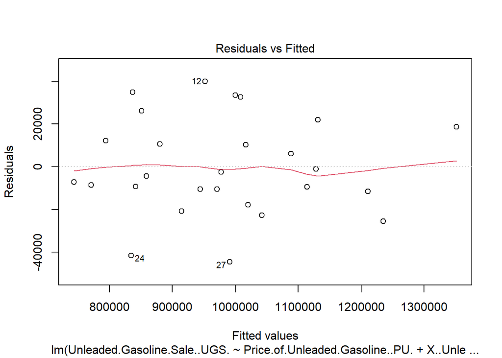

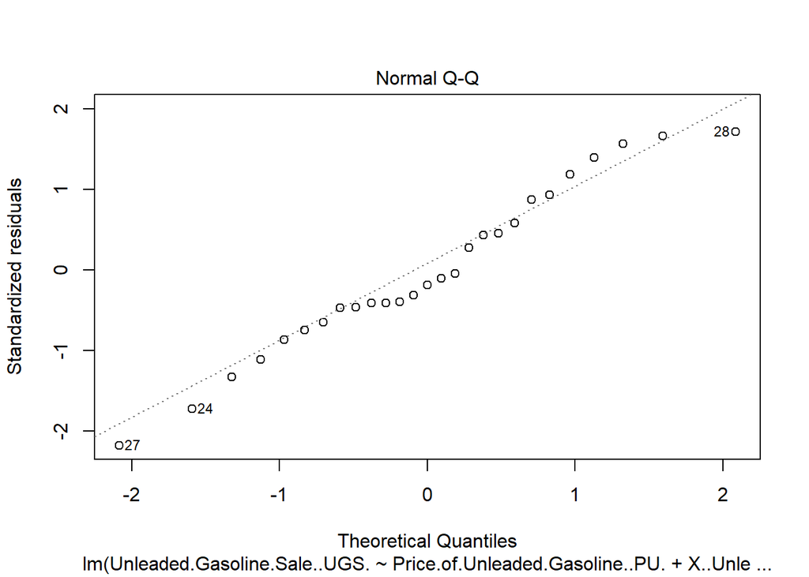

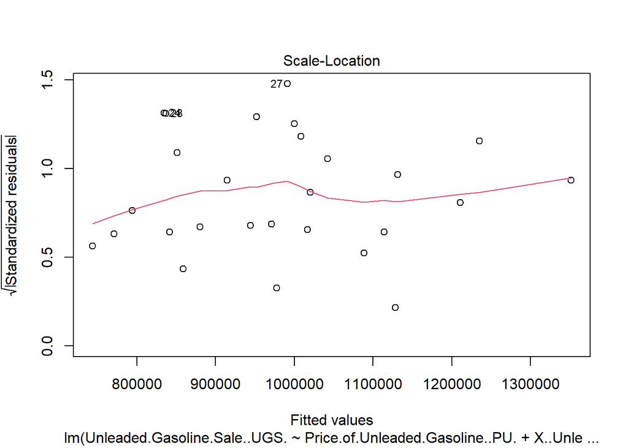

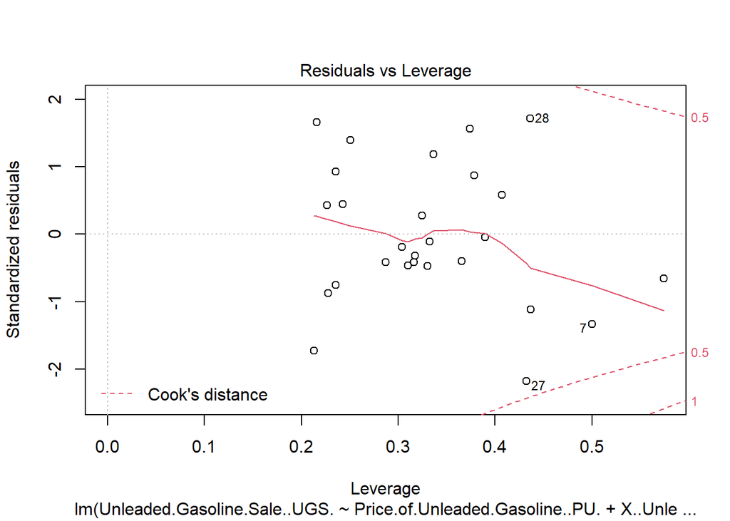

```r
plot(best_model)
```

# Evaluation of the Best

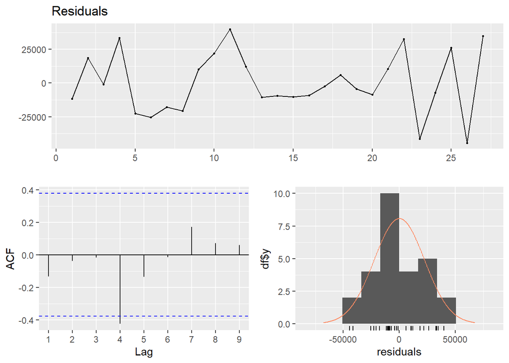

```
##
##  Breusch-Godfrey test for serial correlation of order up to 12
##
## data:  Residuals
## LM test = 20.476, df = 12, p-value = 0.05859
```

```r
checkresiduals(best_model)
```

Even the last model seems problematic at some perspectives. To be more specific, the normalization assumption of residuals is violated at some degree. We can see that from both Q-Q plot and histogram. Also, it can be improved in terms of the variance constancy of the residuals. However, taking account that the violations are not so large and we have a low amount of data, these violations can be ignored. The summary of the last model supports the idea that it is sufficiently good to use. When it comes to autocorrelation of residuals, there is a out of bound value at lag 4. However, lag4 was added to the model and seen that the SSE values and Adj R^2 value gets worse interestingly, it is not decided to be added to the model. Actually, it probably comes from that we already added quarter seasonality to data, which already shows a similar behavior as in lag4.

# Predictions

```r
pred = c()
for(i in 1:4){
  pred[i] = predict(best_model,newdata=data[i+28,])
  if(i+28 < 32){
    data$lag1[i+29] = pred[i]
  }
}
pred
```

```
## [1] 662492.3 845565.1 965974.6 788131.3
```

```r
data$lag1
```

```
##  [1]        NA 1128971.0 1199569.0 1370167.0 1127548.0 1033918.0 1019754.0
##  [8] 1209916.0 1002789.0  893722.0 1027252.0 1153265.0  991981.0  806257.0
## [15]  960556.0 1104825.0  934022.0  832350.0  975165.0 1094823.0  854517.0
## [22]  762559.0  890693.0 1040946.0  793399.0  736580.0  877614.0  946783.0
## [29]  872000.0  662492.3  845565.1  965974.6
```

# Conclusion

To conclude, it is tried to find a good model to predict upcoming values of UGS. To achieve a sufficiently good model, some components (trend, seasonality and lag values) and other input variables that have a possibility to explain our output variable UGS are examined by adding to the model. As a variable selection approach, backward selection process is selected. While removing variables, roughly these considerations are used: improvement in adj R^2, reduction in SSE, meaning of the input variables, correlation between different input variables, correlation between UGS and input variables etc. At the end of the improvement iterations, a sufficiently good model is achieved and it is specified that in what aspects it is strong and how it can be better.